# Praca domowa 1

Jacek Wiśniewski

24/03/2021

### Wstęp

W tej pracy stworzę model predykcyjny do przewidywania ceny telefonu, który następnie przeanalizuję korzystając z wykresów Break Down profile. Skupię się również na analizie działania wykresów Break Down.

### Telefony którymi się będę zajmował

| name | brand | back_camera_mpix | front_camera_mpix | battery_mAh | ram_gb | flash_gb | diag | height_px | width_px | price |
| --- | --- | --- | --- | --- | --- | --- | --- | --- | --- | --- |
| Xiaomi Mi 10T 6+128GB | Xiaomi | 64 | 20 | 5000 | 6 | 128 | 6.67 | 2400 | 1080 | 1999 |
| Samsung Galaxy A21s | Samsung | 48 | 13 | 5000 | 3 | 32 | 6.50 | 1600 | 720 | 699 |
| Samsung Galaxy Note20 | Samsung | 64 | 10 | 4300 | 8 | 256 | 6.70 | 2400 | 1080 | 3749 |

### Przewidywana cena pierwszego telefonu

| 1628.077 |
| --- |

### Wykres Break Down dla pierwszego telefonu

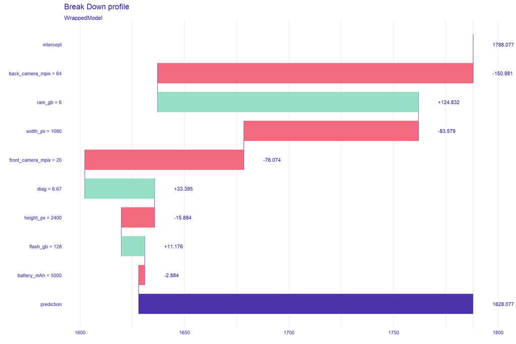

### Wykres Break Down dla drugiego telefonu

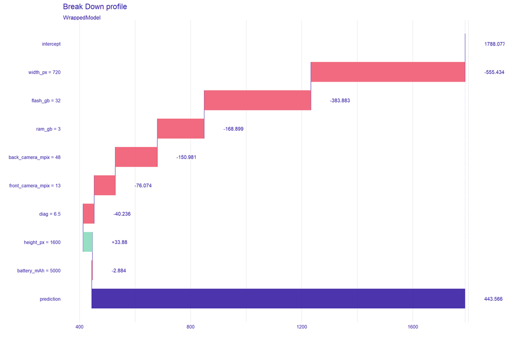

Na wykresach możemy zaobserwować, że na predykcję ceny pierwszego telefonu znacząco wpłynęły zmienne back_camera_mpix oraz ram_gb, za to na predykcję telefonu drugiego najmocniej wpłynęły zmienne width_px i flash_gb.

### Wykres Break Down dla trzeciego telefonu

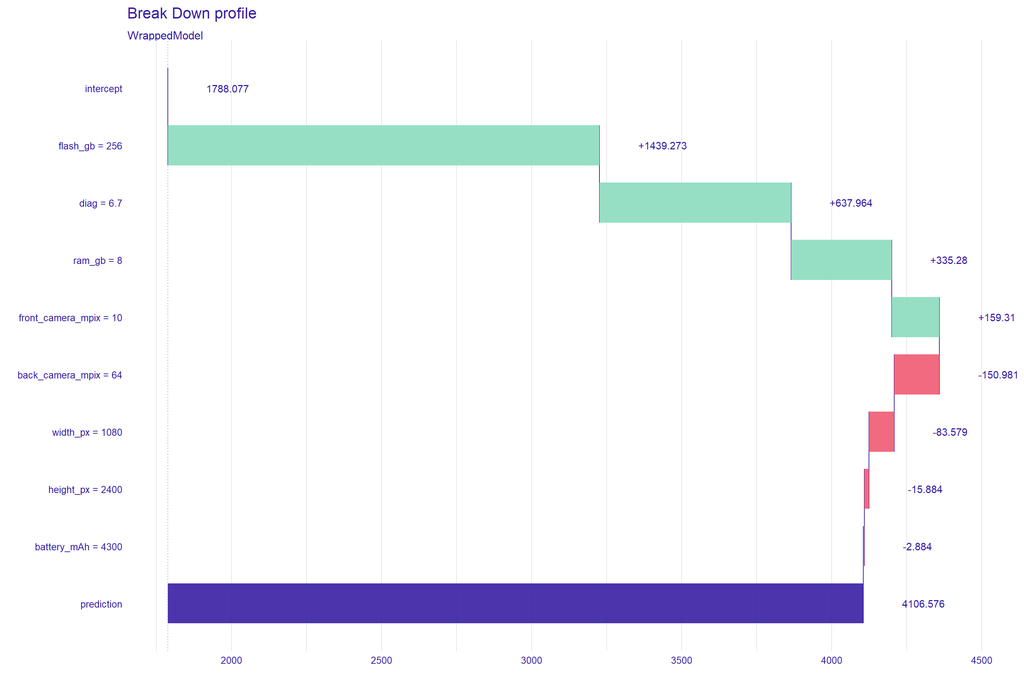

Porównując wykresy drugiego i trzeciego telefonu możemy zauważyć, że zmienna flash_gb w obu przypadkach była istotna dla ostatecznego wyniku predykcji. Różnica polega na tym, że w przypadku drugiego telefonu ta zmienna obniżyła ostateczną cenę, a w przypadku trzeciego telefonu podwyższyła cenę.

### Wnioski

Jak widzimy wykresy break down różnią się od siebie, zarówno jeśli chodzi o dobór najistotniejszych zmiennych, jak i ich wpływ na wynik. Najważniejszą informacją, która częściowo tłumaczy to zjawisko, jest fakt, że każdy z tych wykresów był tworzony niezależnie dla pojedynczych obserwacji o różnych parametrach.

Dla obserwacji ze skrajną wartością parametru ram_gb, ta zmienna może być bardziej istotna dla końcowego wyniku, niż dla obserwacji posiadającej wartość ram_gb w okolicy średniej.

Dodatkowo, jeżeli wartość parametru ram_gb będzie relatywnie duża, to wpływ tej zmiennej na wynik może być dodatni. Jeżeli wartość tego parametru będzie mała, to jej wpływ na wynik może uledz zmienie.

Powyższe przykłady są jedynie uproszczeniami, służącymi wytłumaczeniu, skąd mogą pochodzić róznice w wykresach Break Down. W rzeczywistości powody mogą być znacznie bardziej skomplikowane.